# python_lab_5_quarto

## Лабораторна робота №5. Списки

**Мета:** *освоїти роботу зі списками*

## Створення та обробка списків

### Завдання 1

Жив-був капелюх. У капелюсі не було кролика, натомість був список із п'яти чисел: `1`, `2`, `3`, `4` та `5`.

Ваше завдання:

- напишіть рядок коду, що пропонує користувачеві замінити число всередині списку цілим числом, введеним користувачем (крок 1)
- напишіть рядок коду, який видаляє останній елемент зі списку (крок 2)
- напишіть рядок коду, який друкує довжину існуючого списку (крок 3).

Чи готові до цього випробування?

```python
hat_list = [1, 2, 3, 4, 5]

# Step 1: write a line of code that prompts the user
new_number = int(input("Введіть ціле число для заміни середнього числа: "))
hat_list[2] = new_number

# Step 2: write a line of code that removes the last element from the list.
hat_list.pop()

# Step 3: write a line of code that prints the length of the existing list.
print("Довжина списку:", len(hat_list))

print(hat_list)
```

```
Введіть ціле число для заміни середнього числа: 1
Довжина списку: 4
[1, 2, 1, 4]
```

### Завдання 2

Написати програму сортування списку у порядку зростання методом бульбашки.

```python
def bubble_sort(arr):
    n = len(arr)

    for i in range(n - 1):
        for j in range(0, n - i - 1):
            if arr[j] > arr[j + 1]:
                arr[j], arr[j + 1] = arr[j + 1], arr[j]

my_list = [64, 25, 12, 22, 11]
bubble_sort(my_list)

print("Відсортований список у порядку зростання:")
print(my_list)
```

```
Відсортований список у порядку зростання:
[11, 12, 22, 25, 64]
```

### Завдання 3

Уявіть список - не дуже довгий, не дуже складний, просто звичайний список, що містить деякі цілі числа. Деякі з цих чисел можуть повторюватись, і це ключ до розгадки. Ми не хочемо повторень. Ми хочемо, щоб їх видалили.

Ваше завдання – написати програму, яка видаляє всі дублікати чисел зі списку. Ціль полягає в тому, щоб скласти список, в якому всі числа зустрічаються не більше одного разу.

**Примітка:** припустимо, що вихідний список жорстко закодований всередині коду - Вам не потрібно вводити його з клавіатури. Звичайно, Ви можете покращити код і додати частину, яка може вести діалог з користувачем і отримувати від неї всі дані.

**Підказка:** ми рекомендуємо Вам створити новий список як тимчасову робочу область - вам не потрібно оновлювати список in situ.

Ми не надали тестових даних, оскільки було б надто просто. Натомість ви можете використовувати наш скелет.

```python
my_list = [1, 2, 4, 4, 1, 4, 2, 6, 2, 9]
unique_list = []

for item in my_list:
    if item not in unique_list:
        unique_list.append(item)

print("The list with unique elements only:")
print(unique_list)
```

```
The list with unique elements only:
[1, 2, 4, 6, 9]
```

### Приклад

Уявіть, що Ви розробляєте програмне забезпечення автоматичної метеостанції. Прилад фіксує температуру повітря щогодини та робить це протягом місяця. Це дає Вам загалом 24 × 31 = 744 значення. Спробуємо скласти список, здатний зберігати ці результати.

```python
temps = [[0.0 for h in range(24)] for d in range(31)]
# print(temps)
```

```python
temps = [[0.0 for h in range(24)] for d in range(31)]
#
# The matrix is magically updated here.
#

total = 0.0

for day in temps:
    total += day[11]

average = total / 31

print("Average temperature at noon:", average)
```

```
Average temperature at noon: 0.0
```

### Завдання 4

Погляньте на шахівницю. Кожне поле містить кілька індексів, які необхідно вказати для доступу до вмісту клітини:

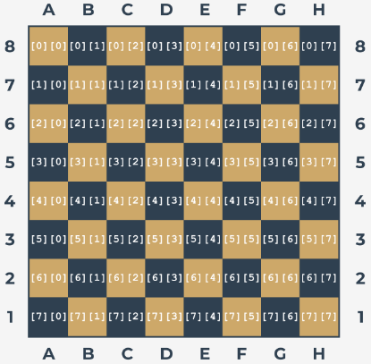

Напишіть код, використоувуючи генератори списків, який створює матрицю 8х8 з пустими клітинками (пуста клітинка задається як "_") для задання шахівниці і розставте чотири тури по кутках шахівниці

```python
chessboard = [['_'] * 8 for _ in range(8)]

chessboard[0][0] = 'R'
chessboard[0][7] = 'R'
chessboard[7][0] = 'R'
chessboard[7][7] = 'R'

for row in chessboard:
    print(' '.join(row))
```

```
R _ _ _ _ _ _ R
_ _ _ _ _ _ _ _
_ _ _ _ _ _ _ _
_ _ _ _ _ _ _ _
_ _ _ _ _ _ _ _
_ _ _ _ _ _ _ _
_ _ _ _ _ _ _ _
R _ _ _ _ _ _ R
```

### Контрольні запитання

1. Який вивод наступного фрагмента?

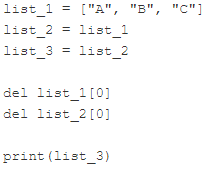

## ['C']

1. Який вивод наступного фрагмента?

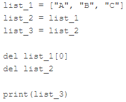

## ['B', 'C']

1. Який вивод наступного фрагмента?

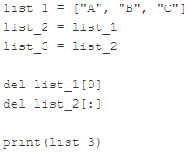

## []

1. Який вивод наступного фрагмента?

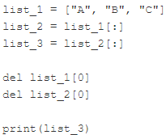

## ['A', 'B', 'C']

### References

1. Anaconda (Python distribution))
2. [Conda](https://conda.io/en/latest/)
3. [Pro Git Book](https://git-scm.com/book/en/v2)
4. [OpenEDG Python Institute](https://pythoninstitute.org/)
5. [Cisco. Networking Academy](https://www.netacad.com/)
6. [Научно-издательская система Quarto](https://data-visualization-blog.netlify.app/posts/quarto/)